# Factors that affect a borrower's loan approval

## by RODOLPH MBAIONDOUM

## Investigation Overview

In this investigation, I wanted to look at the factors or features that could help the loan applicant to get the approval status. The main focus was on the some of the variables like 'Term' , 'LoanStatus', 'BorrowerRate' , 'ProsperScore', 'EmploymentStatus', 'Occupation', 'BorrowerHomeowner', 'StatedMonthlyIncome', 'Recommendations', 'LoanOriginalAmount' , 'IncomeRange'.

## Dataset Overview

The 113,937 loans in this ProsperLoan data set have an average of 81 variables, such as loan amount, borrower rate (or interest rate), current loan status, borrower income, and many more. I focused on a small number of variables because the project objective itself instructs me to keep the visualization simple.

## Prosper rating dependency on Employment status and Income Range

For all the high rating categries like AA, A, B, C , it is quite evident from the graphs that the approval of loans are majorly depend on the applicants income range and Employment status.

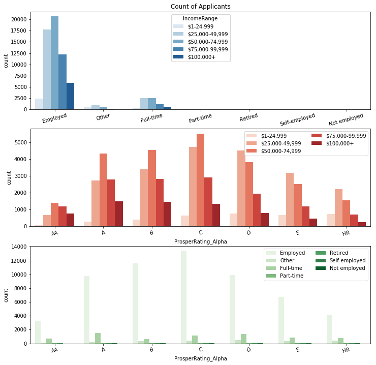

## Applicants rating with borrwers interest rate and homeowner status

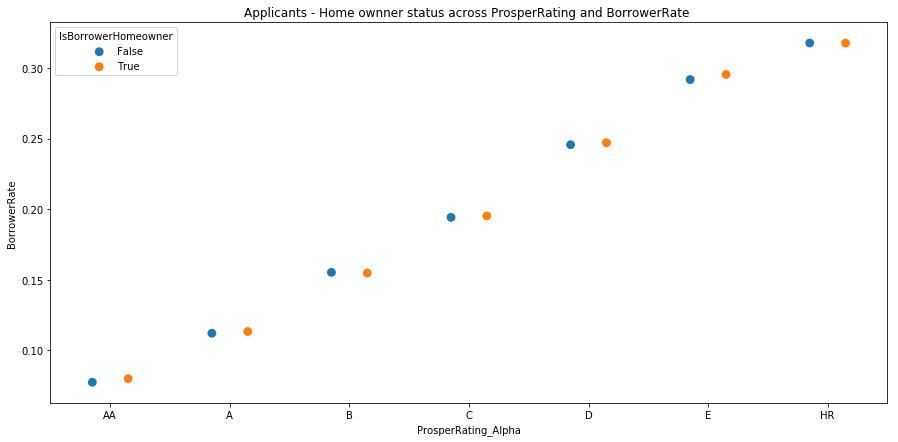

## Applicants rating with monthly income and Employment Status

High rating is given to applicants with employee status having employed and full time and these appicants have higher monthly salary

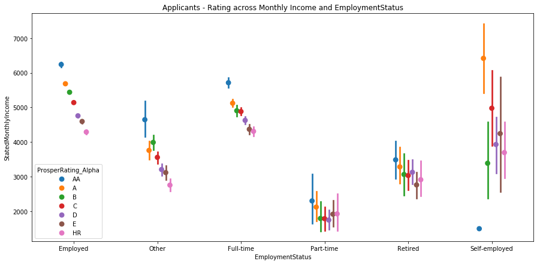